Skip to main content

Think Python

- .ipynb

# 5b. Prof. Rosenthal’s Review

# 5b. Prof. Rosenthal’s Review

A review of [Chapter 5: Conditionals and Recursion](https://y-rosenthal.github.io/yrThinkPython/chap05.html), for students who have already studied the chapter. Use the two lists under **Concepts covered** as a checklist (click a list’s title to hide it), then work through the **Questions**, which go from easy to hard. Each question has a suggested answer under **Answer**. Try the question first, then open the Answer.

[Run this page on Colab](https://colab.research.google.com/github/y-rosenthal/yrThinkPython/blob/v3/yr/chap05_review.ipynb)

## Concepts covered

Python Syntax and Semantics

**Integer division and modulus**

- `X // Y` divides and rounds down to an integer: `105 // 60` is `1`, and `-7 // 2` is `-4`.
- `X % Y` (the modulus operator) is the remainder when X is divided by Y: `105 % 60` is `45`.
- `X % Y == 0` is true when X is divisible by Y. `X % 10` is the last digit of X, and `X % 100` its last two digits.
- `(START + DURATION) % 12` is clock arithmetic: it wraps around after 12 (use `% 24` for a 24-hour clock).

**Boolean expressions**

- `True` and `False` are the two values of the type `bool`. They are not strings.
- The relational operators compare two values and produce `True` or `False`: `X == Y` (equal), `X != Y` (not equal), `X > Y`, `X < Y`, `X >= Y`, `X <= Y`.
- `=` assigns a value to a variable; `==` compares two values.
- `A and B` is true when both are true. `A or B` is true when either or both are true. `not A` is true when A is false. For example, `x > 0 and x < 10` is true when x is between 0 and 10.
- `LOW < X < HIGH` is shorthand for `LOW < X and X < HIGH`.
- Any nonzero number counts as true when used as a condition. (This can be confusing; it is better to use boolean expressions.)

**if statements**

- This runs the indented block only if the condition is true:

  ```
  if CONDITION:
      BLOCK
  ```

  For example, this displays `x is positive` if `x` is greater than `0`:

  ```python
  if x > 0:
      print('x is positive')
  ```

- A block must have at least one statement. `pass` is a statement that does nothing, used as a placeholder.
- With an `else` clause, exactly one of the two blocks runs:

  ```
  if CONDITION:
      BLOCK1
  else:
      BLOCK2
  ```

- A chained conditional checks the conditions in order and runs only the block of the first true one (or the `else` block, if none is true):

  ```
  if CONDITION1:
      BLOCK1
  elif CONDITION2:
      BLOCK2
  else:
      BLOCK3
  ```

  There can be any number of `elif` clauses. The `else` clause is optional, and must come last.
- Separate `if` statements, one after the other, are each checked: several of their blocks can run.
- An `if` statement can be nested inside a block of another one. A nested conditional can often be replaced by one condition with `and`.

**Recursion**

- A function can call itself. Each call has its own parameters and local variables.
- A recursive function needs a base case: a branch that does not make a recursive call. Each recursive call should move closer to the base case.
- Statements after a recursive call run after that call has finished, so they run in the opposite order of the calls.
- If the base case is never reached, the recursion goes on until Python’s limit on the number of frames (about `1000`; the exact number depends on the environment) is exceeded, which is a `RecursionError`.

**Keyboard input**

- `input()` stops the program, waits for the user to type something and press Enter, and returns what they typed, as a string.
- `input(PROMPT)` first displays the prompt. `'\n'` in a string is a newline (a line break), so `input('Your name?\n')` lets the user type below the prompt.
- `int(input())` converts the input to an integer; if the user types something that is not an integer, it is a `ValueError`.

**Error messages**

- Indenting a line that should not be indented is an `IndentationError`.
- Leaving out the colon at the end of an `if` header is a `SyntaxError`, and so is using `=` instead of `==` in a condition.
- An error message says where the error was discovered, which may be after the line where the mistake is.

**The jupyturtle module** (used by one question)

- `make_turtle()` starts a drawing with the turtle in the middle, facing east; `forward(DISTANCE)` moves and draws (a negative distance moves backward); `left(DEGREES)` and `right(DEGREES)` turn; `penup()` and `pendown()` stop and restart drawing.

Definitions, etc.

**Definitions**

- DEFINITION: The **modulus operator**, `%`, computes the remainder when one integer is divided by another.
- DEFINITION: A **boolean expression** is an expression whose value is either `True` or `False`.
- DEFINITION: A **relational operator** is one of the operators that compare their operands: `==`, `!=`, `>`, `<`, `>=` and `<=`.
- DEFINITION: A **logical operator** is one of the operators that combine boolean expressions: `and`, `or` and `not`.
- DEFINITION: A **conditional statement** is a statement that controls which statements run, depending on a condition.
- DEFINITION: A **condition** is the boolean expression in a conditional statement that decides which branch runs.
- DEFINITION: A **block** is one or more statements indented to show they are part of another statement.
- DEFINITION: A **branch** is one of the alternative blocks in a conditional statement.
- DEFINITION: A **chained conditional** is a conditional statement with a series of alternative branches (`if`, `elif`, …, `else`).
- DEFINITION: A **nested conditional** is a conditional statement inside a branch of another conditional statement.
- DEFINITION: **Recursion** is calling the function that is currently running. A function that calls itself is **recursive**.
- DEFINITION: The **base case** is a branch of a recursive function that does not make a recursive call.
- DEFINITION: **Infinite recursion** is a recursion that has no base case or never reaches it. It ends with a runtime error.
- DEFINITION: A **newline** is a character, written `\n`, that makes a line break in a string.

**Other ideas**

- Nested conditionals are hard to read; avoid them when a simpler condition can do the same job.
- `TODO` in a comment is a conventional reminder of something still to be done.
- In a stack diagram of a recursive function, each call has its own frame with its own value of each parameter; the frame of the base case is at the bottom.
- When you see an infinite recursion, check that there is a base case and that every call is guaranteed to reach it.
- The most useful parts of an error message are the kind of error and where it happened. Read error messages carefully, but the actual mistake may be earlier in the code.

## Questions

One question draws a picture with `jupyturtle`, a small turtle-graphics module for Jupyter notebooks. The turtle starts in the middle of the canvas, facing east (to the right). `make_turtle()` starts a new drawing, `forward(d)` moves the turtle `d` units while drawing a line (backward if `d` is negative), `left(a)` and `right(a)` turn it `a` degrees, and `penup()` and `pendown()` stop and restart the drawing.

The setup cell below downloads `jupyturtle` and imports those functions.

```python
from os.path import basename, exists

def download(url):
    filename = basename(url)
    if not exists(filename):
        from urllib.request import urlretrieve

        local, _ = urlretrieve(url, filename)
        print("Downloaded " + str(local))
    return filename

download('https://github.com/ramalho/jupyturtle/releases/download/2024-03/jupyturtle.py');

from jupyturtle import make_turtle, forward, left, right, penup, pendown
```

### Question 1 (easy): what is displayed?

Predict what this code displays, then open the Answer to check.

```python
minutes = 135
print(minutes // 60, minutes % 60)
print(17 % 5, 20 % 5, 3 % 7)
print(7 // 2, -7 // 2)
```

Answer

```
2 15
2 0 3
3 -4
```

135 minutes is 2 hours (`135 // 60`) and 15 minutes left over (`135 % 60`). `20 % 5` is `0` because 20 is divisible by 5, and `3 % 7` is `3` because 7 goes into 3 zero times, with 3 left over. `//` always rounds *down*, so `-7 // 2` is `-4`, not `-3`.

### Question 2 (easy): what is displayed?

```python
x = 5
y = 7
print(x == y, x != y)
print(x < y and y < 10)
print(x > y or y == 7)
print(not x < y)
print(type(True))
```

Answer

```
False True
True
True
False
<class 'bool'>
```

`x < y and y < 10` is true because both parts are true. `x > y or y == 7` is true because one part, `y == 7`, is true. `x < y` is true, so `not x < y` is false. `True` and `False` belong to the type `bool`.

### Question 3 (easy): what is displayed?

```python
def check(n):
    if n % 2 == 0:
        print(n, 'is even')
    else:
        print(n, 'is odd')

check(4)
check(7)
check(0)
```

Answer

```
4 is even
7 is odd
0 is even
```

A number is even when the remainder of dividing it by 2 is `0`. `0 % 2` is `0`, so `0` is even. Exactly one of the two branches runs in each call.

### Question 4 (easy): write a function

Write a function called `sign` that takes a number `x` and displays `positive`, `negative` or `zero`.

Start from this header (replace `...` with the body):

```python
def sign(x):
    ...
```

**Examples**

```python
sign(12)
sign(-0.5)
```

```
positive
negative
```

```python
sign(0)
```

```
zero
```

Answer

A chained conditional, with one branch for each case:

```python
def sign(x):
    if x > 0:
        print('positive')
    elif x < 0:
        print('negative')
    else:
        print('zero')
```

Then try: `sign(12)` and `sign(-0.5)`.

The same thing with a nested conditional, which is harder to read:

```python
def sign(x):
    if x == 0:
        print('zero')
    else:
        if x > 0:
            print('positive')
        else:
            print('negative')
```

### Question 5 (medium): what is displayed?

```python
def grade(score):
    if score >= 60:
        print('pass')
    elif score >= 90:
        print('excellent')
    else:
        print('fail')

grade(95)
grade(70)
grade(30)
```

Answer

```
pass
pass
fail
```

In a chained conditional, only the first true branch runs. For `95`, `score >= 60` is already true, so the `elif` is never checked, and `excellent` is never displayed for any score. To fix it, check `score >= 90` first:

```python
def grade(score):
    if score >= 90:
        print('excellent')
    elif score >= 60:
        print('pass')
    else:
        print('fail')

grade(95)
grade(70)
grade(30)
```

```
excellent
pass
fail
```

### Question 6 (medium): what is displayed?

```python
x = 15
if x > 10:
    print('big')
if x > 5:
    print('medium')
if x > 0:
    print('small')
else:
    print('not positive')
```

Answer

```
big
medium
small
```

These are three separate `if` statements, and each one is checked, so all three blocks whose conditions are true run. The `else` belongs only to the last `if`. With `elif` instead of the second and third `if`, only `big` is displayed:

```python
x = 15
if x > 10:
    print('big')
elif x > 5:
    print('medium')
elif x > 0:
    print('small')
else:
    print('not positive')
```

```
big
```

### Question 7 (medium): what is displayed?

```python
def describe(x):
    if 0 < x < 10:
        print(x, 'is a positive single digit')
    else:
        if x <= 0:
            print(x, 'is not positive')
        else:
            print(x, 'is 10 or more')

describe(5)
describe(-3)
describe(10)
```

Answer

```
5 is a positive single digit
-3 is not positive
10 is 10 or more
```

`0 < x < 10` means `0 < x and x < 10`, which is false for `10`. The nested conditional could be written as one chained conditional:

```python
def describe(x):
    if 0 < x < 10:
        print(x, 'is a positive single digit')
    elif x <= 0:
        print(x, 'is not positive')
    else:
        print(x, 'is 10 or more')
```

```
5 is a positive single digit
-3 is not positive
10 is 10 or more
```

### Question 8 (medium): find the error

Each part has one mistake. Predict the error for each, then open the Answer to check.

**Part a**

```python
x = 5
if x = 5:
    print('five')
```

**Part b**

```python
x = 5
if x > 0
    print('positive')
```

**Part c**

```python
x = 5
 y = 6
```

Answer

**Part a:** `=` assigns; comparing needs `==` (a `SyntaxError`):

```
    if x = 5:
       ^
SyntaxError: invalid syntax. Maybe you meant '==' or ':=' instead of '='?
```

**Part b:** The header of an `if` statement must end with a colon (a `SyntaxError`):

```
    if x > 0
            ^
SyntaxError: expected ':'
```

**Part c:** The second line is indented by one space, but it is not inside a block (an `IndentationError`):

```
    y = 6
    ^
IndentationError: unexpected indent
```

Python finds each of these mistakes before it runs any of that part’s code, so nothing is displayed and `x` is never assigned.

### Question 9 (medium): write a function

Write a function called `end_hour` that takes `start` (an hour on a 24-hour clock, from `0` to `23`) and `duration` (a number of hours), and displays the hour when the event ends, also from `0` to `23`.

Start from this header (replace `...` with the body):

```python
def end_hour(start, duration):
    ...
```

**Examples**

```python
end_hour(9, 3)
end_hour(22, 5)
```

```
12
3
```

```python
end_hour(20, 28)
```

```
0
```

Answer

The remainder after dividing by 24 wraps around midnight:

```python
def end_hour(start, duration):
    print((start + duration) % 24)
```

Then try: `end_hour(9, 3)` and `end_hour(22, 5)`.

22 + 5 is 27, which is 3 more than 24, so the event ends at 3. 20 + 28 is 48, exactly two days, so it ends at 0 (midnight).

### Question 10 (medium): write a function

Write a function called `fizzbuzz` that takes a positive integer `n` and displays `FizzBuzz` if `n` is divisible by both 3 and 5, `Fizz` if it is divisible by 3 only, `Buzz` if it is divisible by 5 only, and otherwise `n` itself.

Start from this header (replace `...` with the body):

```python
def fizzbuzz(n):
    ...
```

**Examples**

```python
fizzbuzz(9)
fizzbuzz(10)
```

```
Fizz
Buzz
```

```python
fizzbuzz(30)
fizzbuzz(7)
```

```
FizzBuzz
7
```

Answer

Check the most specific case first: a number divisible by both 3 and 5 is also divisible by 3, so if `n % 3 == 0` came first, `30` would display `Fizz`.

```python
def fizzbuzz(n):
    if n % 3 == 0 and n % 5 == 0:
        print('FizzBuzz')
    elif n % 3 == 0:
        print('Fizz')
    elif n % 5 == 0:
        print('Buzz')
    else:
        print(n)
```

Then try: `fizzbuzz(9)` and `fizzbuzz(10)`.

A number divisible by both 3 and 5 is divisible by 15, so the first condition can also be `n % 15 == 0`:

```python
def fizzbuzz(n):
    if n % 15 == 0:
        print('FizzBuzz')
    elif n % 3 == 0:
        print('Fizz')
    elif n % 5 == 0:
        print('Buzz')
    else:
        print(n)
```

### Question 11 (medium): write a function

Write a function called `largest` that takes three numbers and displays the largest of them. Use `if` statements (not the built-in function `max`).

Start from this header (replace `...` with the body):

```python
def largest(a, b, c):
    ...
```

**Examples**

```python
largest(3, 9, 4)
largest(10, 2, 7)
```

```
9
10
```

```python
largest(5, 5, 1)
largest(-1, -8, -0.5)
```

```
5
-0.5
```

Answer

`a` is the largest if it is at least as large as each of the others; otherwise the larger of `b` and `c` is:

```python
def largest(a, b, c):
    if a >= b and a >= c:
        print(a)
    elif b >= c:
        print(b)
    else:
        print(c)
```

Then try: `largest(3, 9, 4)` and `largest(10, 2, 7)`.

Using `>=` instead of `>` matters when two numbers are equal: with `a > b and a > c`, `largest(5, 5, 1)` would skip the first branch, but still display `5` from the second one.

Another approach keeps track of the largest so far:

```python
def largest(a, b, c):
    biggest = a
    if b > biggest:
        biggest = b
    if c > biggest:
        biggest = c
    print(biggest)
```

### Question 12 (hard): what is displayed?

```python
def mystery(n, s):
    print('n =', n, 's =', s)
    if n == 0:
        print('result:', s)
    else:
        mystery(n - 1, s + n)

mystery(3, 0)
```

Answer

```
n = 3 s = 0
n = 2 s = 3
n = 1 s = 5
n = 0 s = 6
result: 6
```

Each call passes `n - 1` and `s + n` to the next one, so `s` adds up `3 + 2 + 1`. The call with `n = 0` is the base case: it does not call `mystery` again. In general, `mystery(n, 0)` displays the sum of the integers from 1 to `n`.

### Question 13 (hard): what is displayed?

```python
def up_down(n):
    if n > 0:
        print('*' * n)
        up_down(n - 1)
        print('*' * n)

up_down(3)
```

Answer

```
***
**
*
*
**
***
```

Each call displays its line, makes the recursive call, and displays its line again *after* that call has finished. So the first `print` calls happen in the order 3, 2, 1, and the second ones in the opposite order, 1, 2, 3. The call `up_down(0)` is the base case: its condition is false, so it does nothing.

### Question 14 (hard): infinite recursion

Run this cell to define `countdown_by_two`.

```python
def countdown_by_two(n):
    if n == 0:
        print('Blastoff!')
    else:
        countdown_by_two(n - 2)
```

Two correct ways to call it:

```python
countdown_by_two(4)
```

```
Blastoff!
```

```python
countdown_by_two(10)
```

```
Blastoff!
```

What happens with this call? How would you fix the function? (Try your fix in a new cell, so that the cell above keeps the original code.)

```python
countdown_by_two(5)
```

Answer

The calls get `n` = 5, 3, 1, -1, -3, … and never `0`, so the base case is never reached. This is infinite recursion. It ends when there are too many frames on the stack (a `RecursionError`):

```
----> 1 countdown_by_two(5)

In countdown_by_two(n):
      3         print('Blastoff!')
      4     else:
----> 5         countdown_by_two(n - 2)

... last 1 frames repeated, from the frame below ...

In countdown_by_two(n):
      3         print('Blastoff!')
      4     else:
----> 5         countdown_by_two(n - 2)

RecursionError: maximum recursion depth exceeded
```

Fix it by making the base case catch every number at or below zero:

```python
def countdown_by_two(n):
    if n <= 0:
        print('Blastoff!')
    else:
        countdown_by_two(n - 2)

countdown_by_two(5)
```

```
Blastoff!
```

### Question 15 (hard): write a recursive function

Write a recursive function called `stairs` that takes a positive integer `n` and displays `n` lines: `n` copies of `#`, then `n - 1` copies, and so on, down to one. Do not use a `for` loop.

Start from this header (replace `...` with the body):

```python
def stairs(n):
    ...
```

**Examples**

```python
stairs(3)
```

```
###
##
#
```

```python
stairs(5)
```

```
#####
####
###
##
#
```

Answer

Display the first line, then let a recursive call display the rest. When `n` reaches `0` there is nothing left to do (the base case):

```python
def stairs(n):
    if n > 0:
        print('#' * n)
        stairs(n - 1)
```

Then try: `stairs(3)`.

The same thing with the base case written out:

```python
def stairs(n):
    if n <= 0:
        pass          # nothing to display
    else:
        print('#' * n)
        stairs(n - 1)
```

Moving `print` after the recursive call would display the lines in the opposite order, from one `#` up to `n`.

### Question 16 (hard): write two recursive functions

Write two recursive functions that take a non-negative integer `n` and display its digits, one per line: `digits_backward(n)` from the last digit to the first, and `digits_forward(n)` from the first to the last. Use `% 10` (the last digit) and `// 10` (the number without its last digit), and no loops.

Start from this header (replace `...` with the body):

```python
def digits_backward(n):
    ...

def digits_forward(n):
    ...
```

**Examples**

```python
digits_backward(472)
```

```
2
7
4
```

```python
digits_forward(472)
```

```
4
7
2
```

```python
digits_forward(5)
```

```
5
```

Answer

A number with one digit (less than 10) is the base case. Otherwise, display the last digit and handle the rest recursively, or the other way around:

```python
def digits_backward(n):
    print(n % 10)
    if n >= 10:
        digits_backward(n // 10)

def digits_forward(n):
    if n >= 10:
        digits_forward(n // 10)
    print(n % 10)
```

Then try: `digits_backward(472)`.

The only difference is the order: `digits_forward` displays its digit *after* the recursive call has displayed all the earlier digits. Another way to write the base case:

```python
def digits_forward(n):
    if n < 10:
        print(n)
    else:
        digits_forward(n // 10)
        print(n % 10)
```

### Question 17 (hard): what is drawn?

This recursive function draws with `jupyturtle`. Describe what it draws, then open the Answer to check.

```python
def branch(length):
    if length > 10:
        forward(length)
        left(30)
        branch(length * 0.6)
        right(60)
        branch(length * 0.6)
        left(30)
        forward(-length)

make_turtle(delay=0, height=220)
left(90)            # face up
penup()
forward(-100)       # move down without drawing
pendown()
branch(70)
```

Answer

A tree: a trunk of length 70 that splits into two branches, each of which splits into two, and so on, each time 0.6 times as long, until the length is 10 or less:

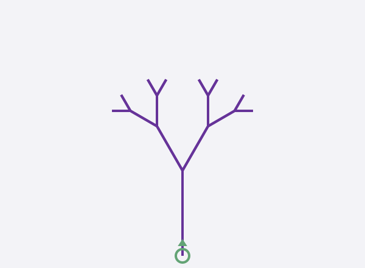

`branch` draws a line, turns left 30 degrees and draws a smaller tree, turns right 60 degrees and draws another smaller tree, then turns back and moves backward to where it started, facing the same way. That last step is important: each call leaves the turtle where it found it, so the next branch starts in the right place. The base case is a length of 10 or less, where nothing is drawn. The lengths are 70, 42, 25.2, 15.12, then 9.072, so there are four levels.

*Summary and questions by Prof. Y. Rosenthal, based on* [Think Python: 3rd Edition](https://allendowney.github.io/ThinkPython/index.html) *by Allen B. Downey.* *Text license:* [Creative Commons Attribution-NonCommercial-ShareAlike 4.0 International](https://creativecommons.org/licenses/by-nc-sa/4.0/)

Contents